# Questions

1. Chivalry existed as we have been told?
2. The richer, the higher chance of survival?
3. What's the age distribution of all passengers?

```
66.67 % of survivor are women.
Conclusion: Chivalry existed.
```

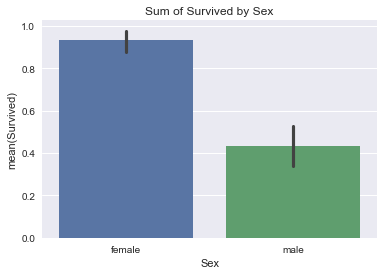

```python
# Question 1: 2-d
# Logic: If more survivors are woman, we say "Chivalry existed".
import numpy as np
import pandas as pd
import matplotlib.pyplot as plt
import seaborn as sns
%matplotlib inline

# Import data from csv and drop missing value
path = 'C:/Users/qzcoo/Google Drive/Data Analyst Program (Udacity)/Profect_Investigate a Dataset/'
data = pd.read_csv(path + 'titanic-data.csv').dropna()
# sex = pd.read_csv(path + 'titanic-data.csv', index_col='sex')

# Extract only related column out as a new table
chivalry = data[['Survived','Sex']]

# Victorized operation used to calculate man_count and woman_count below
man_count = (chivalry['Survived'] == 1) & (chivalry['Sex'] == 'male')
woman_count = (chivalry['Survived'] == 1) & (chivalry['Sex'] == 'female')
num_woman_count = woman_count.sum()
num_sum_count = (man_count | woman_count).sum()
print (round(num_woman_count / num_sum_count*100, 2), "% of survivor are women.")

if num_woman_count / num_sum_count > 0.5:
    print ('Conclusion: Chivalry existed.')
else:
    print ('What is Chivalry?')

##Visualization: Best graph?
sns.barplot(x="Sex", y="Survived", data=chivalry)
sns.plt.title('Sum of Survived by Sex')
```

```
People who pay more have 76.24% chance of survival, compares to 59.67% chance who pay less.
Conclusion: The richer, the higher chance of survival.
```

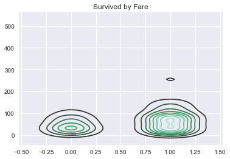

```python
# Question 2: 2-d
# Logic: First sort the whole table by fare in descending order. If top 50% of people who paid more have a higher probability of being saved than last 50%, we say "Money does have power".

# Extract only related column out as a new table, sort by fare in descending order.
moneypower = data[['Survived','Fare']].sort_values(by=['Fare'], ascending=False)
# Truncate the invalid row with fare = 0
moneypower_cleaned = moneypower[moneypower['Fare'] > 0]
num_total = len(moneypower_cleaned)

# Count top 50% and bottom 50% of fare paid people who survived, using pandas function .median(), ignoring the nuance of odd or even total passenger number.
top_count = (moneypower_cleaned['Survived'] == 1) & (moneypower_cleaned['Fare'] >= moneypower_cleaned['Fare'].median())
bottom_count = (moneypower_cleaned['Survived'] == 1) & (moneypower_cleaned['Fare'] < moneypower_cleaned['Fare'].median())

num_top_count = top_count.sum()
num_bottom_count = bottom_count.sum()
per_top = round(num_top_count / (num_total/2.), 4)
per_bottom = round(num_bottom_count / (num_total/2.), 4)

print('People who pay more have {}% chance of survival, compares to {}% chance who pay less.'.format(per_top*100, per_bottom*100))

if per_top > per_bottom:
    print ("Conclusion: The richer, the higher chance of survival.")
else:
    print ("Conclusion: No signifance correlation between fare and survival.")

##Visualization: Best graph?
sns.distplot(moneypower_cleaned, color = ['b', 'y'],vertical=True)
sns.plt.title('Survived by Fare')
```

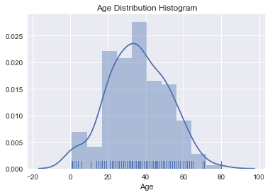

```python
# Question 3: 1-d
# Logic: use seaborn to create a histogram of all passengers' age.

# Extract only age column out as a new table. Drop Null value.
age = data['Age']

sns.distplot(age, rug=True)
sns.plt.title('Age Distribution Histogram')
```

# Conclusion

## 1. Limitation of the data analysis

(1) Sample bias: the difference between the sample and the population, we don't know how the sample was chosen from the actual population of people that were on the Titanic. There could have been some sort of intentional or unintentional bias in how the sample was selected. (2) Missing value bias: as we drop out the missing value in our analysis, there might be a potential bias as we cannot look at the whole picture of the sample.

## 2. Reasoning of each question

(1) Chivalry: If more women than men were survived, we can draw the conclusion that Chivalry existed. So what we need to do is calculating the percentage of women survived out of all survivors. (2) Money Power: If more upper class passengers were survivied, we can say money has power to save your life. So what we do is classifying passengers into two groups by fare paid and testing the survival rate of each group. (3) Age: the passenger age distribution should follow a normal distribution pattern, as we exptected. Based on the histogram, we do see the normal distribution pattern, which means the dataset represents the whole group well.